# Statistics | Scatter Graphs

Before trying to plot a graph, I need to load the packages I want to use (ggplot2 & dplyr, which are part of the tidyverse package), and download my data from vaastav’s Fantasy-Premier-League GitHub page. This repository stores lots of FPL data from the last few seasons, which is very helpful!

I can see that there is a lot of information for each player in each gameweek, including events like goals and clean sheets, statistics like xG, match info like kick-off time and opponent, and FPL-related data like price and position. So there is lots of information to make graphs from! Before making any plots, I usually like to define a theme, which basically just changes the font style of all my plots so they all match. Here is my theme:

```r
# Make theme
theme <- theme_classic() + theme(text = element_text(size = 12, family='Radio Canada Big'))
```

Here, theme_classic() gives the plot a minimalistic style, while element_text() modifies the font.

## Scatter Plot: xG Overperformance

| name | position | team | Goals | xG |
| --- | --- | --- | --- | --- |
| Aaron Cresswell | DEF | West Ham | 0 | 0.00 |
| Aaron Hickey | DEF | Brentford | 0 | 0.20 |
| Aaron Ramsdale | GK | Arsenal | 0 | 0.00 |
| Aaron Ramsey | MID | Burnley | 0 | 0.35 |
| Aaron Wan-Bissaka | DEF | Man Utd | 0 | 0.11 |
| Abdoulaye Doucouré | MID | Everton | 7 | 8.70 |

To make a basic plot, I first specify the dataframe, x and y axes to ggplot(). Then I can add geom_point() to make a scatter graph (and add my theme).

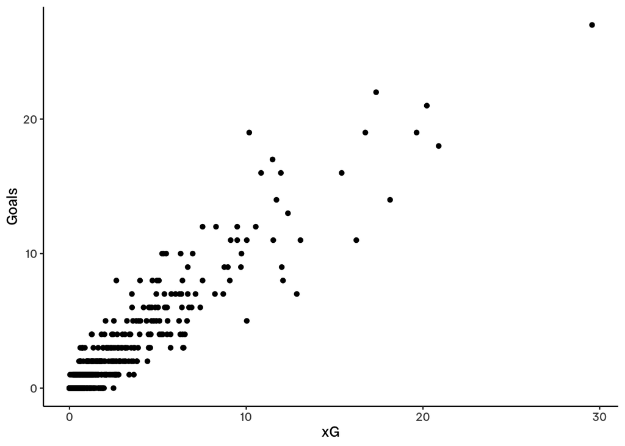

While this graph shows a positive correlation between xG and goals scored, it’s a bit boring and also not very useful. For example, we don’t know who the players are, what position they are, and we can’t tell who had the largest xG overperformance or underperformance. We can change this by adding colours and labels. For example, I could colour the players by their position and use scale_color_manual() to change the colour palette. I can also change the alpha level (transparency) and size of the points.

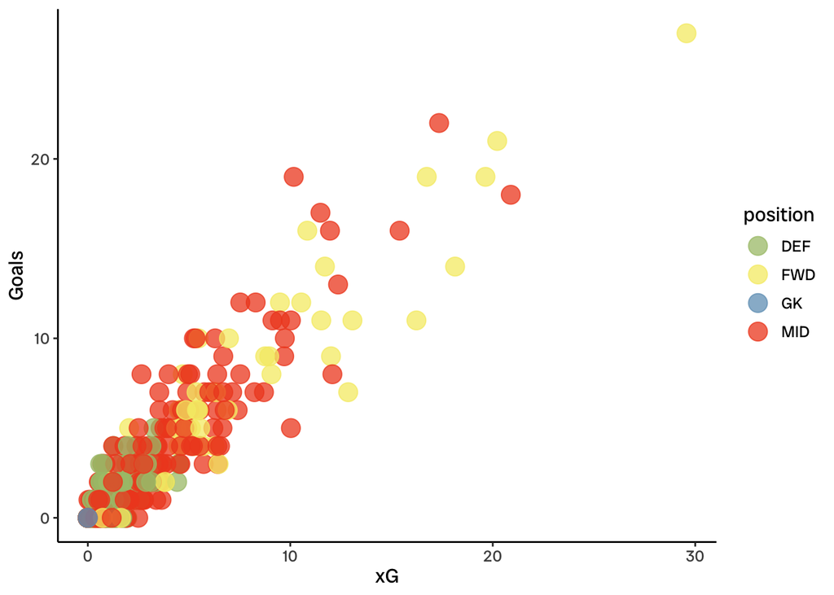

Now I can see that the majority of the biggest goal-scorers are Midfielders and Forwards. But this still isn’t very useful! Perhaps I can also select a subset of players to plot to make it less busy, and add some labels so I can see who the biggest xG underperformers were last year. To do this I could minus xG from total goals scored to get a delta score:

| name | position | team | Goals | xG | Delta |
| --- | --- | --- | --- | --- | --- |
| Dominic Calvert-Lewin | FWD | Everton | 7 | 12.86 | -5.86 |
| Darwin Núñez Ribeiro | FWD | Liverpool | 11 | 16.23 | -5.23 |
| Brennan Johnson | MID | Spurs | 5 | 10.03 | -5.03 |
| Nicolas Jackson | FWD | Chelsea | 14 | 18.14 | -4.14 |
| Luis Díaz | MID | Liverpool | 8 | 12.08 | -4.08 |
| Norberto Bercique Gomes Betuncal | FWD | Everton | 3 | 6.46 | -3.46 |

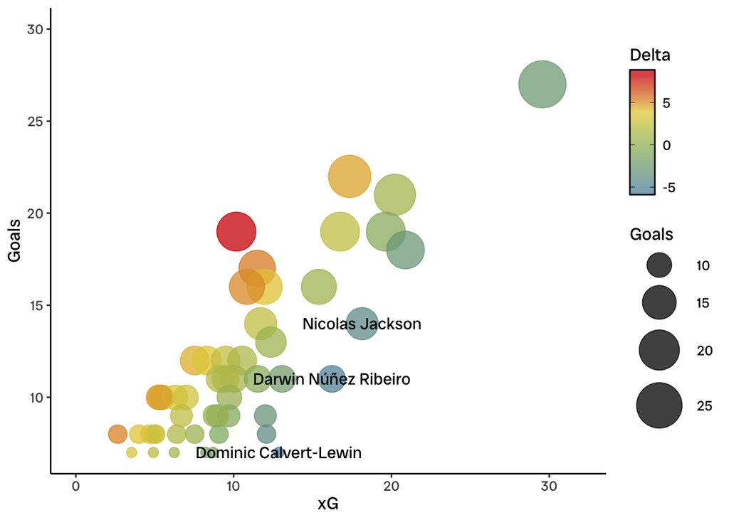

The labels look a bit messy - they are covering some of the other points. I can use the package ggrepel and the argument nudge_x to try and space the labels out so they are more readable:

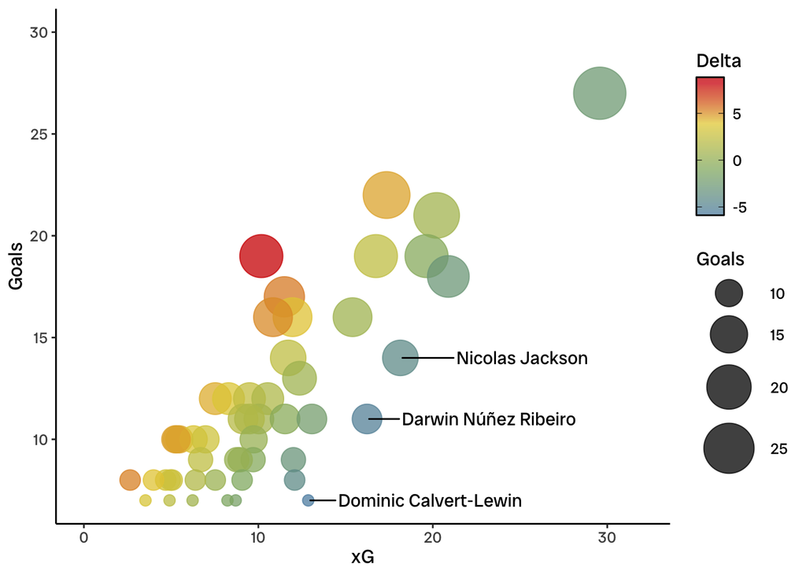